Презентация к докладу

Варианты протокола вручения бита. Подбрасывание монеты по телефону

Исламова С.М.

2 декабря 2025

Российский университет дружбы народов, Москва, Россия

Вводная часть

Актуальность

 Фундаментальный примитив современной криптографии

 Основа электронного голосования, блокчейнов, онлайн-лотерей

 Задача сформулирована Мануэлем Блюмом в 1981–1982 гг.

 Активно развивается в постквантовую эпоху

Цели и задачи работы

Цель работы — изучить принципы работы протоколов вручения бита, их криптографические свойства, а также

рассмотреть классический протокол Мануэля Блюма «подбрасывание монеты по телефону», который позволяет двум

удалённым участникам получить честный случайный результат.

Задачи работы:

 изучить теоретические основы протоколов фиксации значения (commitment);

 объяснить необходимость скрытности и необратимости выбора;

 рассмотреть несколько вариантов протоколов вручения бита;

 описать оригинальный протокол Блюма;

 выявить основные угрозы и методы атак;

 показать практическое значение таких протоколов в современных информационных системах.

2

Теоретическое введение

2.1 Протоколы вручения бита

Протокол вручения бита (Bit Commitment) — это механизм, позволяющий одной стороне (Алисе) зафиксировать

некое значение (бит 0 или 1) таким образом, что:

1. Скрытность (Hiding) — другая сторона (Боб) не может узнать значение до раскрытия.

2. Обязательность (Binding) — Алиса не может изменить значение после фиксации [1;2]

Такие протоколы являются фундаментальными элементами криптографии и используются в:

 электронном голосовании,

 онлайн-аукционах,

 мультипартийных вычислениях,

 блокчейн-системах,

 честных лотереях и протоколах случайного выбора.

Суть протокола аналогична «запечатанному конверту»: Алиса кладёт в конверт число, запечатывает его и передаёт Бобу,

а потом вскрывает его публично.

3

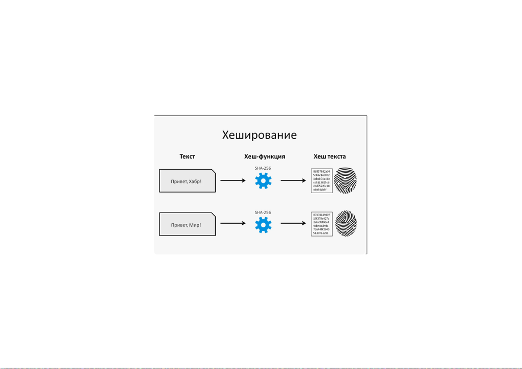

2.1.1 Математическая модель

Для надёжного выполнения требований скрытности и обязательности применяются криптографически стойкие функции:

 хеш-функции — SHA-256, SHA-3 (Рис. 1);

 односторонние функции — вычислить прямое значение легко, обратное — невозможно;

 случайные строки (соли) — обеспечивают непредсказуемость.

Рисунок 1 - Процесс хеширование (функция хеширования)

Пример простого коммитмента:

C = H(b || r)

где

b — бит Алисы,

r — случайное число,

C — коммитмент.

4

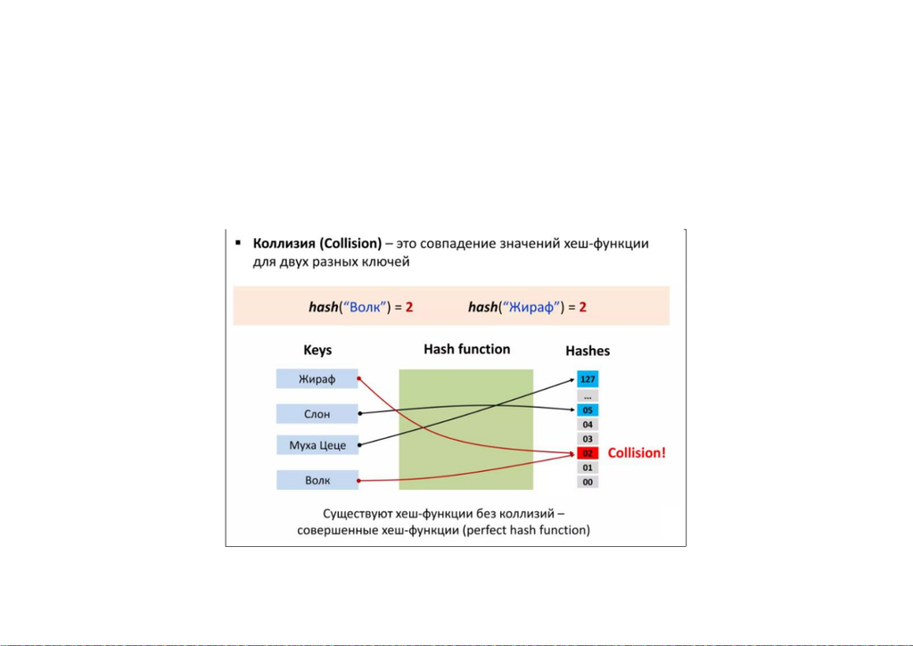

2.1.2 Скрытность коммитмента

Хеш-функции обладают тем свойством, что по хешу невозможно определить исходные данные. Поэтому Боб не может

узнать выбор Алисы до раскрытия.

2.1.3 Обязательность

Если хеш-функция устойчива к коллизиям (рис. 2), Алиса не сможет подобрать другое значение b', r' , дающее тот же

хеш.

Рисунок 2 - Понятие коллизии

5

2.2 Мотивация: честный выбор между удалёнными участниками

Рассмотрим задачу:

две стороны хотят выбрать случайный результат (0 или 1), но не доверяют друг другу.

Без криптографии задача неразрешима:

 если выбор делает Алиса, она может подделать значение;

 если обе стороны говорят одновременно, всегда есть риск подстроить ответ.

Поэтому нужен протокол, при котором:

 Алиса фиксирует значение честно,

 Боб делает выбор независимо,

 итоговый результат не зависит от действий одной стороны.

2.3 Классическая задача: подбрасывание монеты по телефону

Проблему сформулировал М. Блюм в 1982 году [4].

Её смысл:

как двум людям на расстоянии честно симулировать подбрасывание монетки?

Пусть Алиса и Боб общаются по телефону.

Если Алиса говорит «выпал орёл», Боб ей не обязан верить.

Нужен формальный криптографический протокол.

Суть решения:

1. Алиса делает скрытый выбор (0 — орёл, 1 — решка).

2. Боб выбирает значение независимо.

3. Результат определяется XOR двух битов.

6

4. Никто не может обмануть, потому что коммитмент Алисы защищает от подмены.

3 Рассмотрение протоколов

3.1 Базовый протокол на основе хеш-коммитмента

1. Алиса выбирает бит a.

2. Генерирует случайную строку r.

3. Вычисляет коммитмент: C = H(a || r).

4. Посылает коммитмент Бобу.

5. Боб выбирает бит b и отправляет его Алисе.

6. Алиса раскрывает (a, r).

7. Боб проверяет корректность.

8. Итог: a XOR b.[5]

Достоинства:

 простота реализации;

 стойкость при правильном выборе хеша.

Недостатки:

 зависит от криптографических свойств хеша;

 требует аккуратной реализации.

3.2 Протокол с использованием симметричного шифрования

Здесь в качестве коммитмента используется шифрование.

1. Алиса выбирает бит и шифрует его ключом.

2. Передаёт шифртекст.

7

3. После ответа Боба раскрывает ключ.

3.3 Протокол Блюма на квадратичных вычетах

Наиболее строгий математически вариант.

Основан на сложности извлечения квадратного корня по модулю составного числа.

Используется:

 модуль N = p·q (секрет),

 квадратичные вычеты, обладающие необходимыми криптографическими свойствами.

Достоинства:

 строго доказанная безопасность;

 высокая стойкость к атакам.[6]

3.4 Физические протоколы случайного выбора

Используются источники энтропии:

 тепловой шум,

 радиоизлучение,

 атмосферный шум.

Эти методы иногда применяются в распределённых системах генерации ключей.[7]

3.5 Квантовые протоколы честного выбора

Современное направление:

 использование суперпозиции,

 защита на основе невозможности измерить квантовое состояние без его изменения.

Квантовый coin flipping обладает лучшими свойствами в плане честности.[8]

8

4. Выводы

В работе были рассмотрены:

 криптографические основы протоколов фиксации значения,

 механизмы скрытности и обязательности,

 классическая задача «подбрасывания монеты по телефону»,

 базовые и математически строгие протоколы честного выбора,

Изученные протоколы являются основой для:

 систем электронного голосования,

 блокчейна,

 распределённых вычислений,

 честных онлайн-лотерей,

 выбора лидера в распределённых сетях.

Протоколы честного выбора случайности остаются одной из ключевых тем криптографической теории и продолжают

активно развиваться.

9

[figure not shown]

Список источников (литературы)

1. Отраслевой порта. Информационная безопасность бизнеса

2. Протоколы битовых обязательств.Криптографические методы защиты информации в компьютерных системах и

сетях

3. Wikipedia.Криптографическая хеш-функция

4. Wikipedia.Подбрасывание монеты по телефону

5. Управление ключами шифрования и безопасность сети.Лекция 5.Управление ключами

6. Wikipedia.Алгоритм Блюма — Микали

7. Wikipedia.Источник энтропии

8. Dzen.Квантовые протоколы голосования: выборы без фальсификаций

10

Спасибо за внимание!